# Seasonal Reproductive Numbers

David L Smith

2/15/2019

HUB – Roadmap – Library – Transmission, Reproductive Numbers

## .

How do we compute $R_C$ in places where transmission is seasonal? The problem for computing an “average” is that the expected number of cases per case is different depending on when in the year a case was acquired. At the end of the transmission season, most of the infectious days will occur in the trough. The answer to this question involves computing the lead eigenvalue and its associated eigenvector for the next generation operator. Here, we illustrate the concepts by constructing examples.

## Seasonality

We have to be clear on what we mean by “seasonality.” One way to do this is to specify a daily varying vectorial capacity – how many infectious bites would eventually arise from all the mosquitoes feeding on this one human each day of the year? For purposes of this exercise, we will construct these objects assuming seasonality in VC is driven exclusively by seasonality in mosquito densities.

The first step in our algorithm is thus to specify the seasonal pattern in mosquito densities. We will constrain this mathematical object so that we can set the mean intensity of transmission to any value we want. We thus modify it to have an arithmetic mean of one, when averaged over a year. For convenience, the following function constructs several different function families, `ftMozy`, that implement families:

```r
ftMozy = function(t, par){
  UseMethod("ftMozy", par)
}
```

### Trig

A generalized sinusoidal family of functions:

$$M(t) = M \max(0, (1 + a + b \sin(2 \pi (t-s))^p)$$

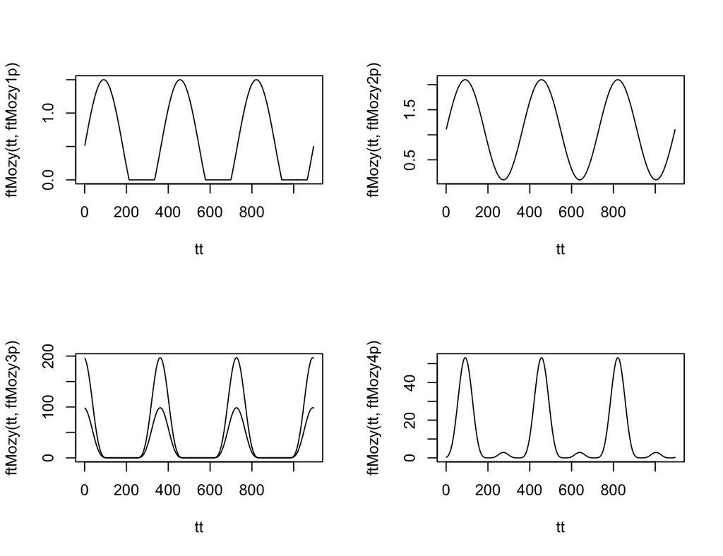

### Block

A two paramter family of functions, called `block2`.
$$M(t) = \begin{array}{rl} a & \mbox{if} (t-s) \mod 365 > v\\ b
& \mbox{if} (t-s) < v \end{array}$$

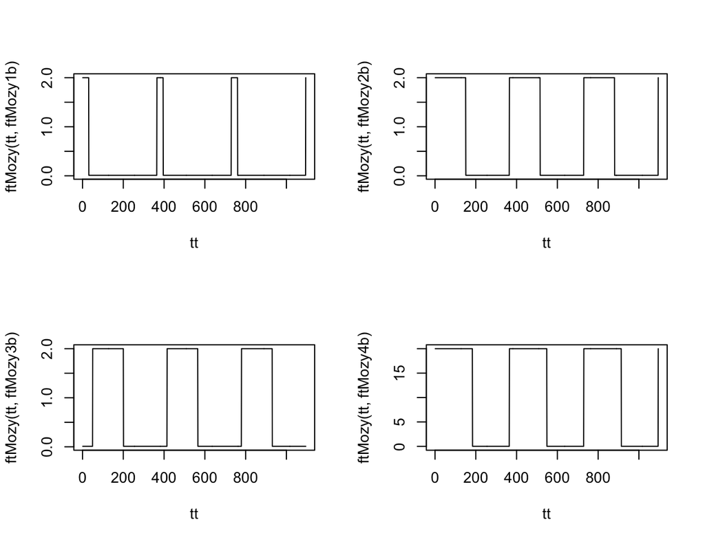

## The Next Generation

### Tmh

$$\begin{equation}
{\cal T}_{M\rightarrow H}(t) = \begin{array}{cl}
0 & \mbox{if } t<t_0 + \tau\\
\frac{fq}{g} e^{-g(t-t_0-\tau)} &\mbox{if } t>t_0 + \tau
\end{array}
\end{equation}$$

To compute the next generation for the temporal operator, we have to be very specific about when the infectious bites occur. VC only describes bites arising, but under the standard model, it is possible to write out a formula describing when they would be expected to occur. Here, we start counting after a mosquito has become infected:

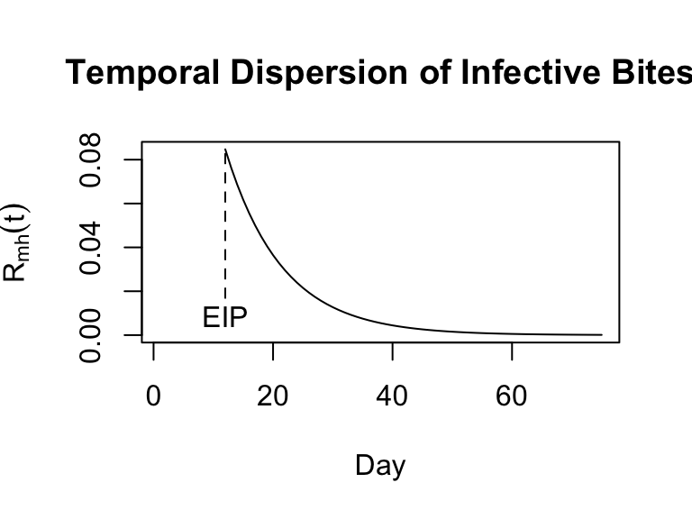

```r
makeTmh = function(EIP=12, p=.9, fq=.3, tol = 0.001, plot=FALSE){
  Vtime = p^c(1:365)
  Vtime[1:(EIP-1)] = 0
  Vtime = fq*Vtime
  cs = cumsum(Vtime)
  Vtime = Vtime[1:min(which(cs>max(cs)-tol))]
  if(plot == TRUE) plotTmh(Vtime, EIP)
  Vtime
}

plotTmh = function(Tmh, EIP){
  ix = 1:length(Tmh)
  plot(ix, Tmh, type ="n",
       xlab = "Day", ylab = expression(R[mh](t)), main = "Temporal Dispersion of Infective Bites")
  vix = ix[-c(1:(EIP-1))]
  lines(vix, Tmh[vix])
  scl = max(Tmh)
  segments(EIP, 0.2*scl, EIP, scl, lty = 2)
  text(EIP, .1*scl, "EIP")
}
```

### HTC and its temporal dispersion

```r
makeDtime = function(D=38, tol = 0.00001, plot=FALSE){
  Dtime = c(rep(0, 17), dgamma(1:730, 2, .03))
  Dt = D*Dtime/sum(Dtime)
  ix = 1:max(which(cumsum(Dt)<D*(1-tol)))
  Dt = Dt[ix]
  Dt = Dt*D/sum(Dt)
  if(plot==TRUE)
    plot(ix, Dt[ix], type = "l", ylab = expression(D(t)), main = "HTC", xlab = "Time (Days)")
  return(Dt)
}
```

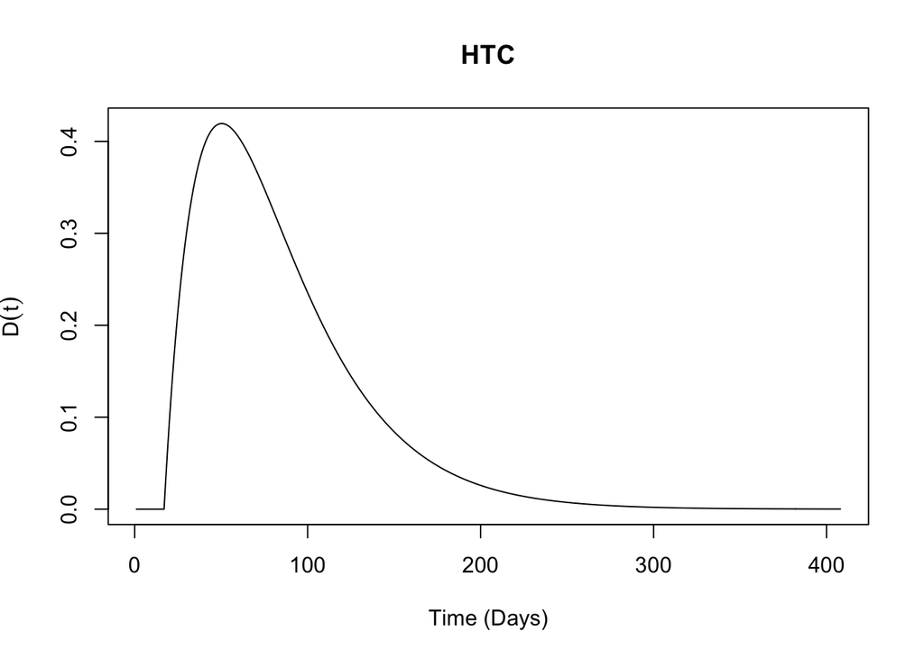

```r
Dt1 = makeDtime(tol=0.0001, plot=TRUE)
```

### Thm

$$\begin{equation}
{\cal T}_{H\rightarrow M}(t,t_1)
= \begin{array}{cl}
0 & \mbox{if } t<t_1\\
fqM(t)c(a) &\mbox{if } t>t_1 + \tau
\end{array}
\end{equation}$$

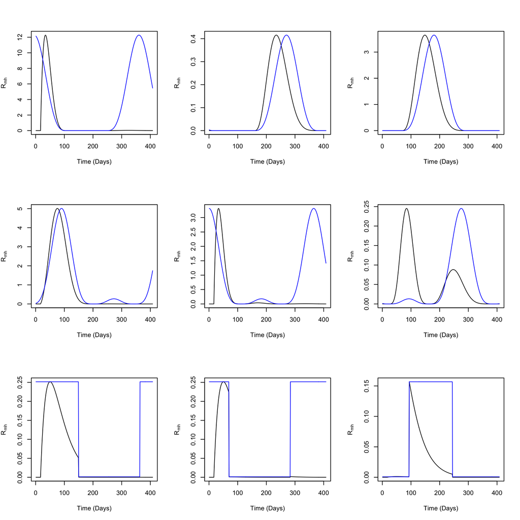

```r
# ftMozy is a canonical seasonal mosquito pattern
makeThm = function(t, Dt, ftMozypar, fq=0.3, plot=FALSE){
  ix = 1:length(Dt)
  Thm = fq*Dt*ftMozy(t + ix, ftMozypar)
  ftMozyt = ftMozy(t+ix, ftMozypar)
  if(plot==TRUE){
    plot(Thm, type = "l", ylab = expression(R[mh]), xlab = "Time (Days)")
    lines(ftMozyt*max(Thm)/max(ftMozyt), col = "blue")
  }
  return(Thm)
}
```

### Serial Interval

```r
makeSerial = function(Tmh, Dt, plot=FALSE){
  mxT = length(Tmh) + length(Dt) +1
  Serial = c(1:mxT)*0
  ix = 1:length(Tmh)
  ixx = 1:length(Dt)

  for(t in ixx) Serial[t+ix] = Serial[t+ix] + Tmh*Dt[t]
  Serial = Serial/sum(Serial)
  if (plot == TRUE){
    plot(Serial/max(Serial), type = "l", main = "", ylab = "Scaled Value", xlab = "Time (Days)", col = "purple", lwd=2)
    lines(Dt/max(Dt), col = "darkblue")
    lines(Tmh/max(Tmh), col = "darkred")
  }
  Serial
}
```

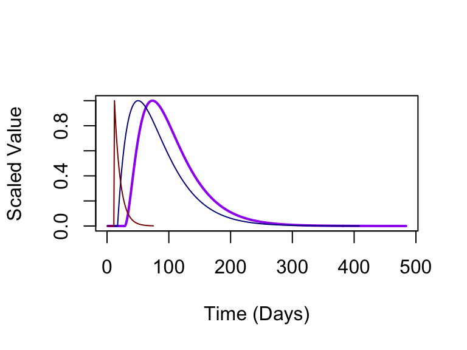

```r
serial = makeSerial(Tmh1, Dt1, plot=TRUE)
```

```r
removeLeadingZeros=function(Rt){
  if(Rt[1,2]>0) return(Rt)
  ix = which(Rt[,2]==0)
  ixx = min(which(diff(ix)>1))
  Rt[-c(1:ixx),]
}

removeTrailingZeros = function(Rt){
  L = length(Rt[,1])
  if(Rt[L,2]>0) return(Rt)
  ix = which(Rt[,2]==0)
  ixx = which(diff(ix)>1)
  if(length(ixx)==0 & max(ix)==L){
    Rt_new = Rt[-ix,]
  } else {
    rmix = c(ix[max(ixx)]+2:L)
    Rt_new = Rt[-rmix,]
  }
  return(Rt_new)
}

rmZeros = function(Rt){
  Rt = removeLeadingZeros(Rt)
  Rt = removeTrailingZeros(Rt)
  return (Rt)
}
```

### One Generation

For a human case that started on some day, when would the next cases arise? This is the question we must take up with the temporal next-generation operator. Given the dispersion in mosquitoes and humans, the temporal dispersion of $R_0$ looks like this:

```r
calR2R = function(ftMozypar, Tmh, Dt, fq=0.3, clr="black", plot=FALSE){
  M = mean(ftMozy(1:365, ftMozypar))
  #print("R0 is approximately:")
  #print(fq*M*sum(Dt)*sum(Tmh))
  ftMozyp = parftMozy.M(M)
  Thm = makeThm(0, Dt, ftMozyp, fq)
  mxT = length(Tmh) + length(Thm) +1
  Rtime = c(1:mxT)*0
  ix = 1:length(Tmh)
  ixx = 1:length(Thm)

  #This does the convolution
  for(i in ixx){
    Rtime[i+ix] = Rtime[i+ix] + Tmh*Thm[i]
  }
  sum(Rtime)
}
```

```r
calR2R(ftMozy3p, Tmh1, Dt1)
ftMozy3p1$M = ftMozy3p$M/474
calR2R(ftMozy3p1, Tmh1, Dt1)
```

```r
calRtime = function(t, Tmh, Dt, ftMozypar, fq=0.3, clr="black", plot=FALSE){
  Thm = makeThm(t, Dt, ftMozypar, fq)
  mxT = length(Tmh) + length(Thm) +1
  Rtime = c(1:mxT)*0
  ix = 1:length(Tmh)
  ixx = 1:length(Thm)

  #This does the convolution
  for(i in ixx){
    Rtime[i+ix] = Rtime[i+ix] + Tmh*Thm[i]
  }
  tt = t + c(1:mxT)
  Rtobj = cbind(tt, Rtime)
  rmZeros(Rtobj)
}
```

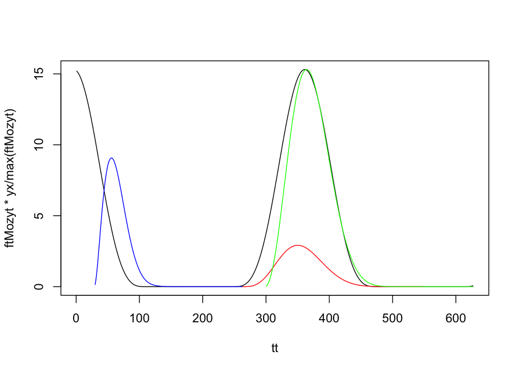

```r
Rt2 = calRtime(0, Tmh1, Dt1, ftMozy3p)
Rt1 = calRtime(180, Tmh1, Dt1, ftMozy3p)
Rt3 = calRtime(270, Tmh1, Dt1, ftMozy3p)
yx =max(Rt2[,2], Rt1[,2], Rt3[,2])
xx =max(Rt2[,1], Rt1[,1], Rt3[,1])
tt = 1:xx
ftMozyt = ftMozy(tt, ftMozy3p)
plot(tt, ftMozyt*yx/max(ftMozyt), ylim = c(0,yx), type = "l")
lines(Rt1, col = "red")
lines(Rt2, col = "blue")
lines(Rt3, col = "green")
```

## Multiple Generations

```r
nextGen = function(thisGen, Tmh, Dt, ftMozypar, fq=0.3){

  t_thisGen = thisGen[,1]
  Rt_thisGen = thisGen[,2]
  t0 = min(t_thisGen)
  tX_thisGen = max(t_thisGen)

  ti = tX_thisGen
  Rt = calRtime(ti, Tmh, Dt, ftMozypar)
  tX = max(Rt[,1])*2

  tt = t0:tX
  nextGen = 0*tt
  for(ti in t_thisGen){
    i = ti-t0+1
    Rt = calRtime(ti, Tmh, Dt, ftMozypar)
    ix = Rt[,1]-t0
    nextGen[ix] = nextGen[ix] + Rt[,2]*Rt_thisGen[i]
  }

  Rtobj = cbind(tt, nextGen)
  rmZeros(Rtobj)
}
```

```r
ftMozyp = ftMozy3p
Rt.1 = calRtime(0, Tmh1, Dt1, ftMozyp)
Rt.2 = nextGen(Rt.1, Tmh1, Dt1, ftMozyp, fq=0.3)

Rt.3 = nextGen(Rt.2, Tmh1, Dt1, ftMozyp, fq=0.3)
Rt.4 = nextGen(Rt.3, Tmh1, Dt1, ftMozyp, fq=0.3)
Rt.5 = nextGen(Rt.4, Tmh1, Dt1, ftMozyp, fq=0.3)
Rt.x = Rt.5
plot(Rt.1, xlim = range(Rt.1[,1], Rt.x[,1]), ylim = range(Rt.1[,2], Rt.x[,2]), type = "l")
lines(Rt.2, col="blue")
lines(Rt.3, col = "purple")
lines(Rt.4, col = "red")
lines(Rt.5, col = "orange")
```

```r
makeNGens = function(t, Tmh, Dt, ftMozyp, fq=0.3, N=10){
  gens = list()
  Rt = calRtime(t, Tmh, Dt, ftMozyp, fq)
  gens[[1]] = Rt
  for(i in 1:N){
    Rt=nextGen(Rt, Tmh, Dt, ftMozyp, fq)
    gens[[i+1]] = Rt
  }
  return(gens)
}
```

```r
plotGens = function(gens, Fclr, offset=0, mx=NULL){
  L = length(gens)
  clr = Fclr(L)

  if(is.null(mx)) {
    xl = c(min(gens[[1]][,1]), max(gens[[L]][,1]))
  } else {
    xl = c(min(gens[[1]][,1]), mx)
  }
  tt = c(1:max(gens[[L]][,1]))/365

  yx = 0
  for(i in 1:L) yx = max(yx,gens[[i]][,2])

  yl = c(0, yx)
  plot(gens[[1]], xlim = xl, ylim = yl, type = "n", ylab = expression(R[0](t)), xlab = "Time (Years)", lwd=2, xaxt = "n")
  axis(1, c(0:10)*365, c(0:10))
  for(i in 1:L){
     ixx = which(gens[[i]][,2]>.00001*max(gens[[i]][,2]))
     #lines(gens[[i]], col=clr[i], lty = (i+2)%%3+1, lwd=2)
     #lines(gens[[i]], col=clr[i], lty = i%%4+1)
     lines(gens[[i]][ixx,1], gens[[i]][ixx,2]+i*offset, col=clr[i])
  }
}

FclrsA = function(N,X=4){
  c1 = rev(viridis(N+X, option = "viridis"))[1:N+X]
  c2 = viridis(N+X, option = "magma")[1:N+X]
  c3 = rev(viridis(N+X, option = "rocket"))[1:N+X]
  as.vector(as.matrix(rbind(c1,c2,c3)))
}

plotGens(gens, FclrsA,mx=3650)
```

```r
ftMozyg = parftMozy.sin(a=0, b=1, p=1, s=270, M=.2)
ftMozyg$M = ftMozyg$M/calR2R(ftMozyg, Tmh1, Dt1)
Mm = ftMozy(tt,ftMozyg)
ftMozyg$M = ftMozyg$M*var(ftMozy(tt,ftMozyg))
ftMozyg = parftMozy.sin(a=0, b=0, p=1, s=270, M=.2)
tt = 1:730
plot(tt, ftMozy(tt,ftMozyg), type = "l")
```

```r
gens = makeNGens(1, Tmh1, Dt1, ftMozyg, N=10)
```

```r
plotGens(gens, FclrsA,mx=3650)
```

```r
pdf("generations.pdf", width=7, height=4)
plotGens(gens, FclrsA,3650)
dev.off(dev.cur())
```

```r
seasonalGens = function(gens){
  L = length(gens)
  getRbyDay=function(t, Rt){
    ty = Rt[,1]%%365+1
    ix=which(ty==t)
    sum(Rt[ix,2])
  }
  seasonMatrix = matrix(0, L, 365)

  for(i in 1:L)
     seasonMatrix[i,] = sapply(1:365, getRbyDay, gens[[i]])
  return(seasonMatrix)
}

seasonalGens(gens)->seasMatrix
```

```r
plotSeasMatrix = function(seasMatrix, N, Fclr, t0=NULL){
  clr1 = viridis(10)[2]
  clr2 = viridis(10)[8]
  L = dim(seasMatrix)[1]
  clrs = Fclr(L)
  yl = c(0, max(seasMatrix))
  yx = max(seasMatrix)
  par(mar = c(1,5,1,2))
  plot(1:365, seasMatrix[1,], type = "l", ylim = yl, col = clr1, lwd=2,  xaxt="n", xlab = "", ylab = expression(R[i](d)))
  lines(1:365, seasMatrix[2,], col=clr2)
  text(50, yx*.85, "Gen 1", col = clr1)
  text(50, yx*.7, "Gen 2", col = clr2)
  if(!is.null(t0)) segments(t0%%365+1, 0, t0%%365+1, yl[2], col = grey(0.3))
  for(i in 1:(N-2)){
    j = 2*i+1
    plot(1:365, seasMatrix[j,], type = "l", ylim = yl, col = clr1, lwd=2, xaxt="n", xlab = "", ylab = expression(R[i](d)))
    lines(1:365, seasMatrix[j+1,], col=clr2)
    lines(1:365, seasMatrix[j-1,], col=grey(0.3), lty=2)
    text(50, yx*.85, paste("Gen ", j), col = clr1)
    text(50, yx*.7, paste("Gen ", j+1), col = clr2)
  }
  par(mar = c(2,5,0,2))
  plot(1:365, seasMatrix[N,], type = "l", ylim = yl, col = clrs[i], xaxt="n",  xlab="Day of Year", ylab = expression(R[i](d)))
  for (i in (j+1):(L-1))
    lines(1:365, seasMatrix[i,], ylim = yl, col = clrs[i])
  lines(1:365, seasMatrix[L,], ylim = yl, col = "black", lwd=2)

#  plot(1:365, seasMatrix[L,], type = "l", ylim = yl, col = "black", lwd=2, xlab="Day of Year, d", ylab = expression(R[i](d)))
}
par(mfrow = c(6,1))
plotSeasMatrix(seasMatrix, 6, FclrsA, 1)
```

```r
pdf("seasonal.pdf", width=3, height=7)
plotSeasMatrix(seasMatrix, 6, FclrsA, 1)
dev.off(dev.cur())
```

```r
contourGens = function(gens){

  L = length(gens)
  t0 = min(gens[[1]][,1])
  tX = max(gens[[L]][,1])
  genMatrix = matrix(0, L, tX-t0+1)

  for(i in 1:L){
    tt = gens[[i]][,1]
    R  = gens[[i]][,2]
    ix = tt-t0+1
    genMatrix[i,ix]=R
  }

  return(genMatrix)
}
contourGens(gens)->genMatrix
filled.contour(genMatrix)
```

```r
image(genMatrix)
```

```r
#layout(c(1,7,7,2,7,7,3,8,8,4,8,8,5,9,9,6,9,9), 6,3 )
M = matrix(c(1:6,7,7,8,8,9,9,7,7,8,8,9,9), 6,3)
layout(M)
plotSeasMatrix(seasMatrix, 6, FclrsA, 1)

serial = makeSerial(Tmh1, Dt1, plot=TRUE)

#Rt2 = calRtime(Tmh1, Dt1, ftMozy3p, t0=90, plot=T)
#Rt1 = calRtime(Tmh1, Dt1, ftMozy3p, t0=270, clr = "green", plot="add")
#Rt3 = calRtime(Tmh1, Dt1, ftMozy3p, t0=20, clr = "red", plot="add")

plotGens(gens, FclrsA,mx=3650)

tt=1:3650
seas =  ftMozy(tt, ftMozy3p)
lines(tt, seas*max(gens[[1]][,2])/max(seas), col = "grey", )
#layout.show(9)
```

```r
GG = 20
Tmh1 = makeTmh()
Dt1 = makeDtime(tol=0.0001)
thisMt = parMt.sin(M=.1,a=-0.1, b=1.3, p=2, s=90)
thisMt$M = 2*thisMt$M/calR2R(thisMt, Tmh1, Dt1)
gens = makeNGens(0, Tmh1, Dt1, thisMt, N=GG)
```

```r
pdf("temporal.pdf", height=8, width=7)
par(mfcol = c(6,2), mar = c(4,5,1,2))

serial = makeSerial(Tmh1, Dt1, plot=TRUE)
text(300, .7, "Serial Interval")
tt = c(1:540)
plot(tt/365, ftMozy(tt, thisMt), type = "l", xlab = "Time (Years)", ylab = expression(M(t)), main = "")
text(1, 0.4, "Mosquito
Population
Density")

clrs = viridis(18)
cR = calRtime(120,Tmh1,Dt1,thisMt)
mx = max(cR[,2])
plot(tt/365, tt*0, type = "n", ylim = c(-0.2*mx, mx), main = "", xlab = "Time(Years)", ylab = expression(R(t)))
for(i in 0:11){
  cR = calRtime(i*30,Tmh1,Dt1,thisMt)
  lines(cR[,1]/365, cR[,2], col = clrs[i+1])
  arrows(i*30/365, -0.05*mx, min(cR[,1])/365, 0, col = clrs[i+1], length = 0.01)
  points(i*30/365, -0.05*mx, pch = 15, col = clrs[i+1], cex=.8)
  points(min(cR[,1])/365, 0, pch = 19, col = clrs[i+1], cex=.8)
}
text(1.2, 0.037, "Seasonal
Reproductive
Success")

FclrsA = function(N,X=2){
  N = floor(N/5)
  c1 = viridis(N+X, option = "viridis")[1:N+X]
  c2 = viridis(N+X, option = "magma")[1:N+X]
  c3 = viridis(N+X, option = "mako")[1:N+X]
  c(c1,c2,c3,c1,c2,c3)
  #as.vector(as.matrix(rbind(c1,c2,c3)))
}
plotGens(gens, FclrsA, mx=5*365)
text(900,.04, "Overlapping Generations")
seasonalGens(gens)->seasMatrix

success = rowSums(seasMatrix)
plot(success[-1]/success[-GG], type = "l", xlab="Generations", ylab = "Ratio")
text(11, 2.5, "Success Across Generations")
segments(0, success[GG], 20, success[GG], lty = 2 )
plot(1:365, seasMatrix[GG,], type = "l", col = "black", lwd=2, xlab="Day of Year, d", ylab = expression(R[i](d)))

text(100, .05, "Seasonal
Eigenvector")
plotSeasMatrix(seasMatrix, 6, FclrsA, 1)
dev.off(dev.cur())
```